# CHIẾN THẮNG TRONG TAY - ck2-11-2026-p5

**Câu 201.** Nhận định nào sau đây **không** đúng: Suất điện động của nguồn điện

**A.** Là đại lượng đặc trưng cho khả năng sinh công của nguồn điện.

**B. #** Nhỏ hơn hiệu điện thế giữa hai cực của nguồn khi mạch kín.

**C.** Có trị số bằng hiệu điện thế giữa hai cực khi mạch ngoài hở.

**D.** Được đo bằng thương số công A của lực lạ làm dịch chuyển một điện tích dương q từ cực âm đến cực dương trong nguồn và độ lớn điện tích q đó.

**Câu 202.** Một giáo viên điều chỉnh hiệu điện thế cung cấp cho một tụ điện phẳng trong phòng thí nghiệm tăng từ 50V lên 100V. Trong trường hợp này, điện dung của tụ sẽ thay đổi như thế nào?

**A.** Giảm 2 lần.

**B.** Tăng 4 lần.

**C. #** Không đổi

**D.** Tăng 2 lần.

**Câu 203.** Khi nói về nguồn điện, phát biểu nào dưới đây là **sai?**

**A.** Nguồn điện là cơ cấu để tạo ra và duy trì hiệu điện thế nhằm duy trì dòng điện trong mạch.

**B.** Để tạo ra các cực nhiễm điện, cần phải có lực thực hiện công tách và chuyển các electron hoặc ion dương ra khỏi điện cực, lực này gọi là lực lạ.

**C.** Mỗi nguồn có hai cực nhiễm điện trái dấu cực dương và cực âm.

**D. #** Mỗi nguồn điện có một suất điện động và điện trở trong phụ thuộc vào dòng điện chạy qua nguồn.

**Câu 204.** Điện trở nhiệt NTC được sử dụng trong mạch bảo vệ thiết bị điện tử vì

**A. #** Điện trở của nó giảm khi nhiệt độ tăng, giúp giới hạn dòng điện khởi động.

**B.** Điện trở của nó giảm khi nhiệt độ giảm, giúp tăng dòng điện.

**C.** Điện trở của nó không thay đổi khi nhiệt độ thay đổi.

**D.** Điện trở của nó tăng khi nhiệt độ tăng, giúp giảm dòng điện khi quá nhiệt.

**Câu 205.** Dòng diện trong kim loại là dòng chuyển dời có hướng của

**A.** Các prôtôn cùng chiều điện trường.

**B.** Các ion âm ngược chiều điện trường.

**C.** Các ion dương cùng chiều điện trường.

**D. #** Các electrôn tự do ngược chiều điện trường.

**Câu 206.** Đại lượng không có đơn vị vôn là

**A.** Hiệu điện thế.

**B.** Điện thế.

**C.** Suất điện động.

**D. #** Thế năng.

**Câu 207.** Đơn vị của cường độ dòng điện là

**A.** Vôn

**B.** Cu lông.

**C.** Jun.

**D. #** Ampe.

**Câu 208.** Đại lượng đặc trưng cho khả năng tích điện của tụ điện là

**A.** Điện tích.

**B. #** Điện dung.

**C.** Điện lượng.

**D.** Hằng số điện môi.

**Câu 209.** Biểu thức xác định năng lượng của tụ điện có điện dung C, đặt vào một hiệu điện thế U là

**A.** $W = \frac{1}{2}CU$

**B. #** $W = \frac{1}{2}CU^{2}$

**C.** $W = CU$

**D.** $W = CU^{2}$

**Câu 211.** Nguyên nhân gây ra điện trở của kim loại là do sự va chạm của:

**A.** Các ion dương nút mạng với nhau trong quá trình chuyển động nhiệt hỗn loạn.

**B.** Các electron tự do với nhau trong quá trình chuyển động nhiệt hỗn loạn.

**C. #** Các electron tự do với chỗ mất trật tự của ion dương nút mạng.

**D.** Các ion dương chuyển động định hướng dưới tác dụng của điện trường.

**Câu 212.** Khi cắm đầu dây nguồn chiếc tủ lạnh vào ổ điện 220V, điều gì xảy ra với các điện tích tự do trong mạch điện?

**A.** **#** Các điện tích tự do di chuyển có hướng tạo ra dòng điện nhờ sự chênh lệch điện thế.

**B.** Các điiện tích tự do sẽ chuyển động theo chiều điện trường.

**C.** Các điện tích không chuyển động ngay khi nhiệt độ trong tủ lạnh đang âm.

**D.** Các điện tích tự do chuyển động với tốc độ bằng tốc độ lan truyền của điện trường.

**Câu 213.** Một nguồn điện có suất điện động E=12V và điện trở trong r=1Ω. Mắc nguồn điện này với một điện trở ngoài R=5Ω. Hiệu điện thế giữa hai cực của nguồn là:

**A. #** 10 V

**B.** 20 V

**C.** 60 V

**D.** 12 V

**Câu 214.** Suất điện động của nguồn điện là đại lượng đặc trưng cho khả năng

**A.** thực hiện công của các lực lạ bên trong nguồn điện.

**B.** tạo ra điện tích dương trong một giây.

**C.** # sinh công trong mạch điện.

**D.** dự trữ điện tích của nguồn điện.

**Câu 215.** Phát biểu nào sau đây là **đúng**?

**A.** Sau khi nạp điện, tụ điện có năng lượng, năng lượng đó tồn tại dưới dạng hoá năng.

**B.** Sau khi nạp điện, tụ điện có năng lượng, năng lượng đó tồn tại dưới dạng cơ năng.

**C.** Sau khi nạp điện, tụ điện có năng lượng, năng lượng đó tồn tại dưới dạng nhiệt năng.

**D.** # Sau khi nạp điện, tụ điện có năng lượng, năng lượng đó là năng lượng của điện trường trong tụ điện.

**Câu 216.** Trong các thiết bị sau, thiết bị nào không sử dụng tụ điện?

**A.** # Tuabin nước.

**B.** Máy khử rung tim.

**C.** Pin dự phòng.

**D.** Bếp từ.

**Câu 217.** Chỉ ra câu **sai**.

**A.** Cường độ dòng điện được đo bằng ampe kế.

**B.** # Dòng điện chạy qua ampe kế đi vào chốt âm, đi ra chốt dương của ampe kế.

**C.** Dòng điện chạy qua ampe kế đi vào chốt dương, đi ra chốt âm của ampe kế.

**D.** Để đo cường độ dòng điện, phải mắc nối tiếp ampe kế với mạch điện.

**Câu 218.** Một dây dẫn bằng đồng có dòng điện 5A chạy qua. Trong khoảng thời gian 4 phút điện lượng dịch chuyển qua tiết diện thẳng của dậy dẫn là

**A.** 20 C.

**B.** 240 C

**C.** 1,25 C.

**D.** # 1200 C.

**Câu 219.** Hình dưới đây là điện trở nhiệt PTC. Nhận định nào sau đây là đúng?

[figure not shown]

**A.** Điện trở nhiệt PTC có giá trị giảm khi nhiệt độ tăng.

**B.** PTC là thiết bị dùng để đo hiệu điện thế.

**C.** Điện trở nhiệt PTC là thiết bị dùng để đo cường độ dòng điện.

**D.** # Điện trở nhiệt PTC có giá trị tăng khi nhiệt độ tăng.

**Câu 220.** Xét một đoạn dây dẫn có tiết diện thẳng S. Trong khoảng thời gian $\Delta t$ điện lượng dịch chuyển qua tiết diện thẳng S là $\Delta q$. Cường độ dòng điện chạy trong đoạn dây được xác định theo biểu thức nào sau đây?

**A.** # $I = \frac{\Delta q}{\Delta t}$.

**B.** $I = \Delta q.\Delta t$.

**C.** $I = \frac{\Delta t}{\Delta q}$.

**D.** $I = \frac{\Delta q}{e}$.

**Câu 221 (TLN) (VD).** Cho dòng điện 4,5 A chạy qua một đoạn dây dẫn bằng kim loại có đường kính tiết diện 2,5 mm. Biết mật độ electron tự do trong dây dẫn này là 8,45.10<sup>28</sup> electron/m<sup>3</sup>. Cho e =1,6.10<sup>-19</sup>C <sub>,</sub> $\pi = 3,14$, vận tốc trôi của các electron tạo ra dòng điện này bằng x.10<sup>-5</sup> m/s. x có giá trị bằng bao nhiêu? (Kết quả làm tròn đến hàng phần mười).

# 6,8

**Câu 222 (TLN) (VD).** Suất điện động của nguồn điện một chiều là 3 V. Công của lực lạ làm dịch chuyển một lượng điện tích q = 4.10<sup>-3</sup> C giữa hai cực bên trong nguồn điện bằng bao nhiêu mJ?

# 12

Câu 223. Điện năng tiêu thụ trên đoạn mạch cho bởi biểu thức

A. A = RI<sup>2</sup>.

B. A = UI.

C. # A = UIt.

D. A = UI<sup>2</sup>t.

**Câu 224.** Đơn vị đo điện năng tiêu thụ là J hoặc

A. # kW.h.

B. kV.

C. k Ω.$\ k\Omega$

D. KW.

**Câu 225.** Đặt hiệu điện thế 6V vào hai đầu điện trở 2Ω. Cường độ dòng điện chạy qua điện trở là

A. 0,5A.

B. 6A.

C. 2A.

D. # 3A.

**Câu 226.** Trong hệ đơn vị SI, đơn vị đo điện trở là

A. # ôm (Ω <sub>)</sub>.

B. fara (F).

C. henry (H).

D. oát (W).

**Câu 227.** Một đoạn dây dẫn có điện trở coi như không đổi, khi hiệu điện thế giữa hai đầu dây dẫn tăng thì

A. cường độ dòng điện chạy qua dây dẫn không thay đổi.

B. cường độ dòng điện chạy qua dây dẫn giảm, tỉ lệ với hiệu điện thế.

C. # cường độ dòng điện chạy qua dây dẫn tăng, tỉ lệ với hiệu điện thế.

D**.** cường độ dòng điện chạy qua dây dẫn có lúc tăng, có lúc giảm.

**Câu 228.** Một bóng đèn có ghi thông số 9 V – 4,5 W được đặt vào một hiệu điện thế không đổi 8,1 V. Cường độ dòng điện qua đèn là

A. 0,5 A.

B. # 0,45 A.

C. 2 A.

D. 0,56 A.

**Câu 229. ****Một mạch điện kín gồm nguồn điện suất điện động E = 6V, điện trở trong r = 0,5Ω, mạch ngoài gồm biến trở R<sub>x</sub> mắc song song với một điện trở R = 1 Ω. Điều chỉnh R<sub>x</sub> để công suất tiêu thụ ở mạch ngoài đạt giá trị cực đại. Gía trị R<sub>x</sub> là:

A. 4 Ω.

B. # 1 Ω.

C. 1,5 Ω.

D. 2 Ω.

[HD]
mắc song song với $R = 1\Omega\$⇒ Điện trở tương đương mạch ngoài: $R_{ng} = \frac{R \cdot R_{x}}{R + R_{x}} = \frac{1 \cdot R_{x}}{1 + R_{x}}$
Công suất tiêu thụ ở mạch ngoài **cực đại khi**:
$$R_{ng} = r$$
Ở đây:
$${r = 0,5\Omega
}{R_{x} = 0,5(1 + R_{x})
}{R_{x} = 0,5 + 0,5R_{x}
}{R_{x} - 0,5R_{x} = 0,5
}{0,5R_{x} = 0,5
}{R_{x} = 1\Omega
}$$

**Câu 230 (Đ/S) (VD).** Một chiếc máy điều hòa không khí trong phòng khách có ghi 220V-2200W được sử dụng với hiệu điện thế 220V.

b) # Công suất định mức là 2200 W.

c) Điện năng mà máy điều hòa tiêu thụ trong 2 giờ là 15840 KJ.

d) Biết rằng mỗi ngày sử dụng 2 giờ và một số điện có giá là 1500 đồng/kW.h. Tiền điện phải trả cho việc sử dụng máy điều hòa trong 30 ngày là 99000 đồng.

**Câu 231.** Trên cục sạc dự phòng có ghi nội dung “10 000 mAh" biểu thị cho dung lượng của sạc dự phòng. Trị số có đơn vị mAh càng lớn thì

**A. #** pin có thể cung cấp năng lượng lâu hơn.

**B.** điện thoại xử lí tốc độ lướt web chậm hơn.

**C.** dòng điện sạc càng mạnh.

**D.** thời gian sạc pin càng ngắn.

**Câu 232.** Suất điện động của một nguồn điện có giá trị bằng

**A.** hiệu các độ giảm thế ở mạch ngoài và mạch trong.

**B.** độ giảm thế ở mạch ngoài.

**C.** độ giảm thế ở mạch trong.

**D. #** tổng các độ giảm thế ở mạch ngoài và mạch trong.

**Câu 233.** Trên đồ thị biểu diễn đường đặc trưng vôn – ampe của một điện trở R, nếu đường thẳng càng dốc thì

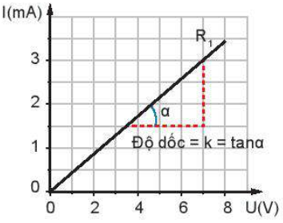

**A.** hiệu điện thế giữa hai đầu điện trở càng nhỏ.

**B. #** điện trở R càng nhỏ.

**C.** dòng điện qua điện trở càng lớn.

**D.** điện trở R càng lớn.

**Câu 235.** Suất điện động của một nguồn điện có giá trị bằng

**A.** hiệu các độ giảm thế ở mạch ngoài và mạch trong.

**B.** độ giảm thế ở mạch ngoài.

**C.** độ giảm thế ở mạch trong.

**D. #** tổng các độ giảm thế ở mạch ngoài và mạch trong.

### **Câu 236.** Tụ điện được sử dụng trong rất nhiều thiết bị điện, trong số đó ứng dụng phổ biến nhất là

**A.** dùng trong máy hàn công nghệ phóng điện của tụ, mạch khuếch đại.

**B.** cho dòng điện một chiều đi qua.

**C.** cho dòng điện một chiều và dòng điện xoay chiều đi qua

**D. #** cho dòng điện xoay chiều đi qua.

**Câu 240.** Suất điện động của nguồn điện là đại lượng đặc trưng cho khả năng

**A.** tích điện cho hai cực của nguồn.

**B.** # thực hiện công của nguồn.

**C.** tác dụng lực của nguồn.

**D.** dự trữ điện tích của nguồn.

**Câu 241.** Đòng điện chạy trong mạch có cường độ I. Trong khoảng thời gian t, điện lượng q chuyển qua mạch được xác định bằng biểu thức

**A.** q = $\frac{I}{t}$

**B.** q = $\frac{t}{I}$

**C. #** q = I.t

**D.** q = I<sup>2</sup>.t

**Câu 242.** Mỗi nguồn điện được đặc trưng bằng

**A.** suất điện động

**B.** điện trở ngoài và suất điện động

**C.** # điện trở trong và suất điện động

**D.** điện trở trong

**Câu 243.** Một mạch điện kín gồm nguồn điện có suất điện động E và điện trở trong r mạch ngoài có điện trở R. Hiệu điện thế hai đầu điện trở R là U. Biểu thức cường độ dòng điện trong mạch là

**A.** I = $\frac{E}{R}$

**B.** I = $\frac{U}{R + \ r}$

**C.** # I = $\frac{E}{R + \ r}$

**D.** I = $\frac{U}{r}$

**Câu 244.** Số Vôn ghi trên mỗi nguồn điện cho biết

**A.** điện trở trong của nguồn điện.

**B.** # suất điện động của nguôn điện.

**C.** hiệu điện thế giữa hai vật.

**D.** dòng điện đi qua nguồn điện.

**Câu 245.** Đường đặc trưng Vôn - Ampe biểu diễn sự phụ thuộc của cường độ dòng điện qua một điện trở vào hiệu điện thế hai đầu vật dẫn là đường

**A.** # thẳng

**B.** parabol.

**C.** elip

**D.** hyperbol.

**Câu 246.** Chiều quy ước của dòng điện là cùng chiều dịch chuyển có hướng của các

**A.** neutron

**B.** điện tích âm

**C.** # điện tích dương

**D.** electron

**Câu 247.** Đặc điểm của điện trở nhiệt NTC là

**A.** điện trở tăng khi nhiệt độ tăng

**B.** # điện trở giảm khi nhiệt độ tăng.

**C.** không phụ thuộc vào nhiệt độ

**D.** điện trở không đổi khi nhiệt độ giảm.

**Câu 248.** Gọi A là công của lực lạ làm di chuyển điện lượng q qua nguồn. Suất điện động E của nguồn được xác định bởi biểu thức nảo sau đây?

**A.** E = q/A

**B.** E = - q/A

**C.** E = q.A

**D.** # E = A/q

**Câu 249.** Điện lượng 1 Culông là lượng điện tích chuyển qua tiết diện thẳng của đây dẫn

**A.** khi có cường độ dòng điện 1 A chạy qua dây dẫn.

**B.** khi có hiệu điện thế 1 V đặt vào hai đầu dây dẫn.

**C.** # trong 1 s khi có cường độ dòng điện 1 A chạy qua dây dẫn.

**D.** trong 1 s khi có cường độ dòng điện chạy qua dây dẫn.

**Câu 251 (TLN) (VD).** Một nguồn điện có điện trở trong 0,2 Ω được mắc nối tiếp với điện trở 4,8 Ω thành mạch kín. Khi đó điện thế giữa hai cực của nguồn điện là 12 V. Suất điện động của nguồn điện bằng bao nhiêu Vôn?

# 12,5

**Câu 252.** Tụ điện là

**A.** hệ thống hai vật dẫn đặt cách nhau một khoảng đủ xa.

**B.** hệ thống gồm hai vật dẫn đặt tiếp xúc với nhau và được bao bọc bằng điện môi.

**C.** hệ thống gồm hai vật đặt gần nhau và ngăn cách nhau bằng một lớp cách điện.

**D.** # hệ thống gồm hai vật dẫn đặt gần nhau và ngăn cách nhau bằng một lớp cách điện.

**Câu 253.** Nếu chiều dài và đường kính của một dây dẫn bằng đồng có tiết diện tròn được tăng lên gấp đôi thì điện trở của dây dẫn sẽ

**A.** tăng lên hai lần.

**B.** không thay đổi.

**C.** # giảm đi hai lần.

**D.** tăng lên gấp bốn lần.

**Câu 254.** Xét dòng điện có cường độ 2 A chạy trong một dây dẫn. Điện lượng chuyển qua tiết diện thẳng của dây dẫn trong 5 s có độ lớn

**A.** # 10 $C$.

**B.** 0,4 $C$.

**C.** 2,5 $C$.

**D.** 7,0 $C$.

**Câu 255.** Với một tụ điện xác định, nếu hiệu điện thế hai đầu tụ tăng 2 lần thì năng lượng điện trường của tụ

**A.** không đổi.

**B.** tăng 2 lần.

**C.** giảm 4 lần.

**D.** # tăng 4 lần.

**Câu 256.** Chỉ ra câu **sai**.

**A.** # Dòng điện chạy qua ampe kế đi vào chốt âm, đi ra chốt dương của ampe kế.

**B.** Để đo cường độ dòng điện, phải mắc nối tiếp ampe kế với mạch điện.

**C.** Cường độ dòng điện được đo bằng ampe kế.

**D.** Dòng điện chạy qua ampe kế đi vào chốt dương, đi ra chốt âm của ampe kế.

**Câu 257.** Cặp số liệu ghi trên vỏ tụ điện cho biết điều gì?

**A.** Phân biệt được tên của các loại tụ điện.

**B.** Năng lượng của điện trường trong tụ điện.

**C.** # Điện dung của tụ và giới hạn của hiệu điện thế đặt vào hai cực của tụ.

**D.** Giá trị nhỏ nhất của điện dung và hiệu điện thế đặt vào hai cực của tụ.

**Câu 258.** Số electron đi qua tiết diện thẳng của một dây dẫn kim loại trong 1 s khi có điện lượng 30 C dịch chuyển qua tiết diện của dây dẫn đó trong 30 s là

**A.** 30.10<sup>18</sup>.

**B.** 90.10<sup>18</sup>.

**C.** # 6,25.10<sup>18</sup>.

**D.** 3.10<sup>18</sup>.

**Câu 259.** Năng lượng của tụ điện bằng

**A.** # công để tích điện cho tụ điện.

**B.** tổng điện thế của các bản tụ điện.

**C.** khả năng tích điện của tụ điện.

**D.** điện thế của các điện tích trên các bản tụ điện.

**B.** Sau khi nạp điện, tụ điện có năng lượng, năng lượng đó là năng lượng của điện trường trong tụ điện.

**C.** Sau khi nạp điện, tụ điện có năng lượng, năng lượng đó tồn tại dưới dạng cơ năng.

**D.** Sau khi nạp điện, tụ điện có năng lượng, năng lượng đó tồn tại dưới dạng nhiệt năng.

**Câu 261.** 1pF bằng

**A.** # 10<sup>-12</sup> F.

**B.** 10<sup>-3</sup> F.

**C.** 10<sup>-9</sup> F.

**D.** 10<sup>-6</sup> F.

**Câu 262.** Nếu hiệu điện thế giữa hai bản tụ tăng 4 lần thì điện dung của tụ

**A.** # không đổi.

**B.** giảm 2 lần.

**C.** tăng 2 lần.

**D.** tăng 4 lần.

**Câu 263.** Chọn phát biểu **đúng** về định luật Ohm.

**A.** Cường độ dòng điện chạy qua dây dẫn tỉ lệ nghịch với hiệu điện thế giữa hai đầu dây dẫn và tỉ lệ thuận với điện trở của dây.

**B.** Cường độ dòng điện chạy qua dây dẫn tỉ lệ với hiệu điện thế giữa hai đầu dây dẫn và điện trở của dây.

**C.** # Cường độ dòng điện chạy qua dây dẫn tỉ lệ thuận với hiệu điện thế giữa hai đầu dây dẫn và tỉ lệ nghịch với điện trở của dây.

**D.** Cường độ dòng điện chạy qua dây dẫn tỉ lệ thuận với hiệu điện thế giữa hai đầu dây dẫn và không tỉ lệ với điện trở của dây.

**Câu 264.** Dòng điện trong kim loại là

**A.** dòng dịch chuyển của điện tích.

**B.** # dòng dịch chuyển có hướng của các điện tích tự do.

**C.** dòng dịch chuyển có hướng của các hạt mang điện.

**D.** dòng dịch chuyển có hướng của các ion dương và âm.

**Câu 265.** Trên vỏ một tụ điện có ghi $20pF - 200V$. Tụ điện tích trữ được năng lượng tối đa là

**A.** $4.10^{- 4}J$.

**B.** # $4.10^{- 7}J$.

**C.** $8.10^{- 7}J$.

**D.** $4.10^{5}J$.

**Câu 266.**

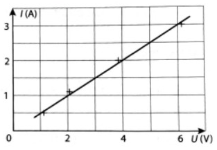

Đồ thị I – U của một vật dẫn được biểu diễn như hình bên. Chỉ ra câu **đúng, sai** trong các nhận định sau:

**a)** # Đường biểu diễn sự phụ thuộc của cường độ dòng điện I chạy qua vật dẫn vào hiệu điện thế U đặt vào hai đầu vật dẫn được gọi là đường đặc trưng vôn – ampe của vật dẫn đó.

**b)** Đồ thị biểu diễn mối liên hệ giữa I và U không tuân theo định luật Ohm.

**c)** # Đường đặc trưng vôn – ampe là một đoạn thẳng.

**d)** Điện trở của vật dẫn này là 0,5 $\Omega$.

**Câu 267 (TLN) (VD).**

[figure not shown]

Đồ thị trong hình cho thấy sự phụ thuộc của U vào Q của một tụ điện. Xác định C theo đơn vị mF.

# 1